# COVID-19 Outbreak of Mexico

M.C.D.Mendis

7/18/2020

# $\underline{Introduction}$

### **Location of the Mexico**

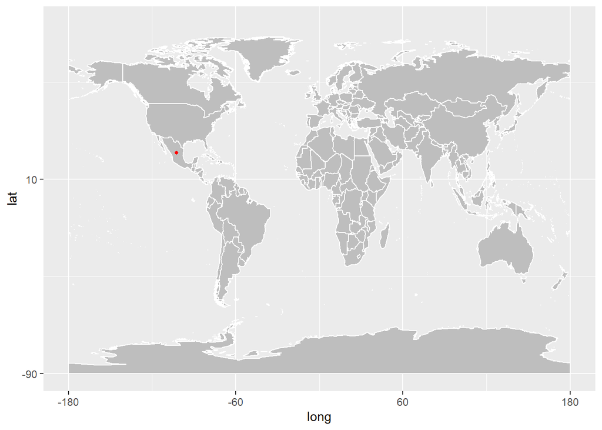

[output not shown]

Mexico is located in Middle America, bordering the Caribbean sea and the Gulf of Mexico, between Belize and the US and bordering the North Pacific Ocean, between Guatemala and the US. Capital of Mexico: Mexico City

### **Climate condition of Mexico**

The climate in Mexico is tropical with a rainy and dry season and little temperature fluctuation from season to season. The temperature in all areas of Mexico typically ranges between 50F and 90F throughout the year. Average annual humidity is around 70%. The temperature in winter averages between 20 and 24 degrees Celsius (high 68 to 74 Fahrenheit) and in summer the average temperature is around 28 degree Celsius (83 Fahrenheit). October through May is the city’s dry season, which means this period has very little rain.

### **Government actions against Corona Pandemic**

• Several governors have felt the need to put in place stricter protective measures than those of the federal government.

• Eighteen states have imposed a mix of measures, such as obligatory stay-at-home orders, the mandatory use of face masks, and fines for social gatherings.

• Twenty five of Mexico’s 32 states are offering small and medium-sized businesses tax incentives and credits beyond the limited fiscal stimulus provided by the federal government. • A few state leaders suspended schools and universities before the federal government and, together with business groups, have called Lopez Obrador’s response insufficient.

• Several governors have felt the need to put in place stricter protective measures than those of the federal government.

• Eighteen states have imposed a mix of measures, such as obligatory stay-at-home orders, the mandatory use of face mask, and fines for social gatherings.

• Twenty five of Mexico’s 32 states have been offered small and medium-sized businesses tax incentives and credits beyond the limited fiscal stimulus provided by the federal government.

# $\underline{Exploratory Data Analysis}$

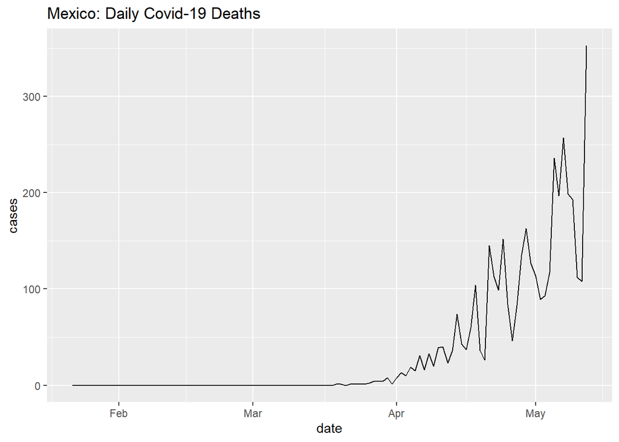

```
        date province country     lat      long  type cases
1 2020-01-22           Mexico 23.6345 -102.5528 death     0
2 2020-01-23           Mexico 23.6345 -102.5528 death     0
3 2020-01-24           Mexico 23.6345 -102.5528 death     0
4 2020-01-25           Mexico 23.6345 -102.5528 death     0
5 2020-01-26           Mexico 23.6345 -102.5528 death     0
6 2020-01-27           Mexico 23.6345 -102.5528 death     0
```

```
  mean_cases
1   35.05357
```

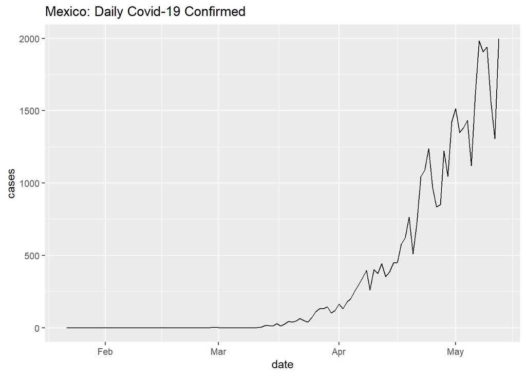

```
        date province country     lat      long      type cases
1 2020-01-22           Mexico 23.6345 -102.5528 confirmed     0
2 2020-01-23           Mexico 23.6345 -102.5528 confirmed     0
3 2020-01-24           Mexico 23.6345 -102.5528 confirmed     0
4 2020-01-25           Mexico 23.6345 -102.5528 confirmed     0
5 2020-01-26           Mexico 23.6345 -102.5528 confirmed     0
6 2020-01-27           Mexico 23.6345 -102.5528 confirmed     0
```

```
  mean_cases
1   342.1786
```

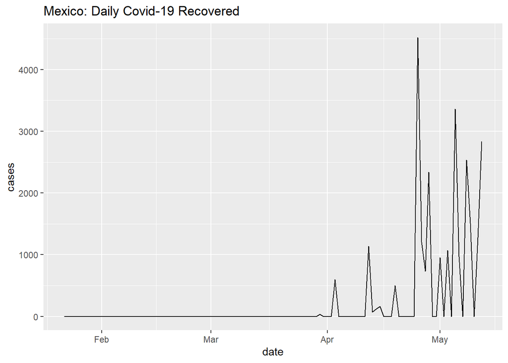

```
        date province country     lat      long      type cases
1 2020-01-22           Mexico 23.6345 -102.5528 recovered     0
2 2020-01-23           Mexico 23.6345 -102.5528 recovered     0
3 2020-01-24           Mexico 23.6345 -102.5528 recovered     0
4 2020-01-25           Mexico 23.6345 -102.5528 recovered     0
5 2020-01-26           Mexico 23.6345 -102.5528 recovered     0
6 2020-01-27           Mexico 23.6345 -102.5528 recovered     0
```

```
  mean_cases
1   231.5625
```

Recovery has been started to report on end of the March. It become rapidly increased after end of the April. Average recovery cases per day is 232.

```
# A tibble: 112 x 8
   date       province country   lat  long confirmed death recovered
   <date>     <chr>    <chr>   <dbl> <dbl>     <int> <int>     <int>
 1 2020-01-22 ""       Mexico   23.6 -103.         0     0         0
 2 2020-01-23 ""       Mexico   23.6 -103.         0     0         0
 3 2020-01-24 ""       Mexico   23.6 -103.         0     0         0
 4 2020-01-25 ""       Mexico   23.6 -103.         0     0         0
 5 2020-01-26 ""       Mexico   23.6 -103.         0     0         0
 6 2020-01-27 ""       Mexico   23.6 -103.         0     0         0
 7 2020-01-28 ""       Mexico   23.6 -103.         0     0         0
 8 2020-01-29 ""       Mexico   23.6 -103.         0     0         0
 9 2020-01-30 ""       Mexico   23.6 -103.         0     0         0
10 2020-01-31 ""       Mexico   23.6 -103.         0     0         0
# ... with 102 more rows
```

```
# A tibble: 112 x 9
   date       province country   lat  long confirmed death recovered active
   <date>     <chr>    <chr>   <dbl> <dbl>     <int> <int>     <int>  <int>
 1 2020-01-22 ""       Mexico   23.6 -103.         0     0         0      0
 2 2020-01-23 ""       Mexico   23.6 -103.         0     0         0      0
 3 2020-01-24 ""       Mexico   23.6 -103.         0     0         0      0
 4 2020-01-25 ""       Mexico   23.6 -103.         0     0         0      0
 5 2020-01-26 ""       Mexico   23.6 -103.         0     0         0      0
 6 2020-01-27 ""       Mexico   23.6 -103.         0     0         0      0
 7 2020-01-28 ""       Mexico   23.6 -103.         0     0         0      0
 8 2020-01-29 ""       Mexico   23.6 -103.         0     0         0      0
 9 2020-01-30 ""       Mexico   23.6 -103.         0     0         0      0
10 2020-01-31 ""       Mexico   23.6 -103.         0     0         0      0
# ... with 102 more rows
```

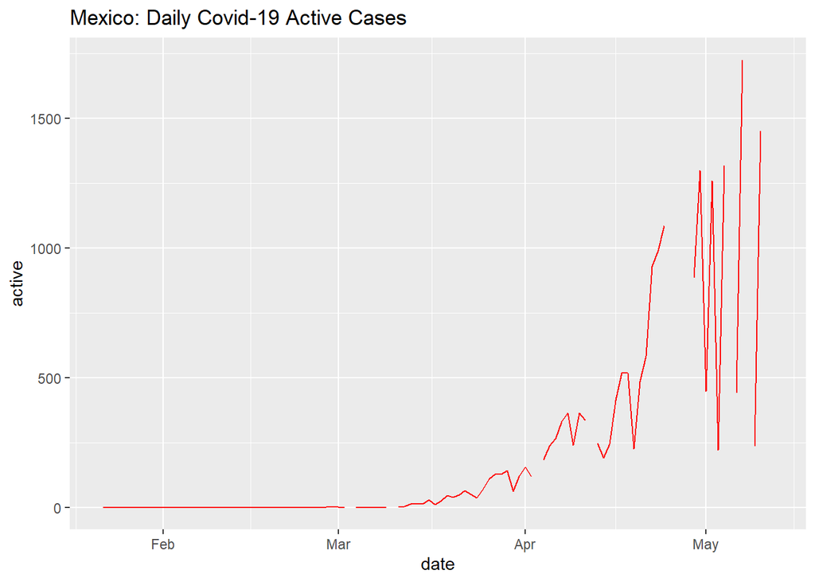

```
# A tibble: 1 x 1
  mean_active
        <dbl>
1        75.6
```

Active cases become rapidly increased begining of the month of May.Average Active cases per day is 76.

### **Comparison with other countries**

The reason to compare with Guatemala, US and Belize; there are boarder jumpers with those neighboring countries where COVID-19 cases are on the rise. Italy has reported more than twice as many deaths than China because those countries compared with Mexico.

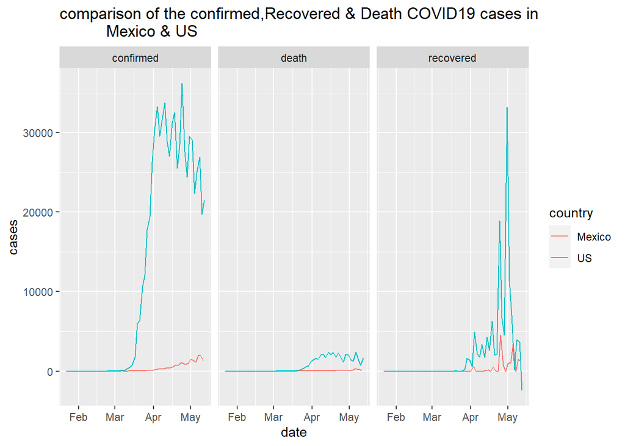

When we compare US with Mexico, US got reported high number of cases in every aspect, however US have reached satisfactory recovery rate.

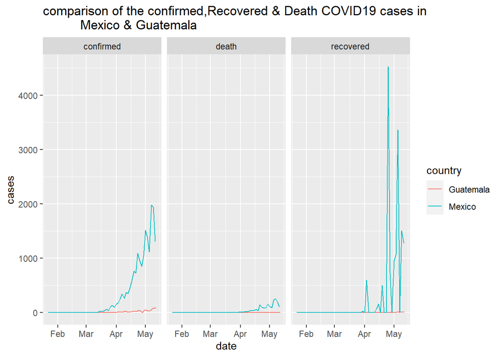

Guatemala has very few cases and deaths compared to Mexico, but Mexico reached a satisfactory recovered rate to Guatemala.

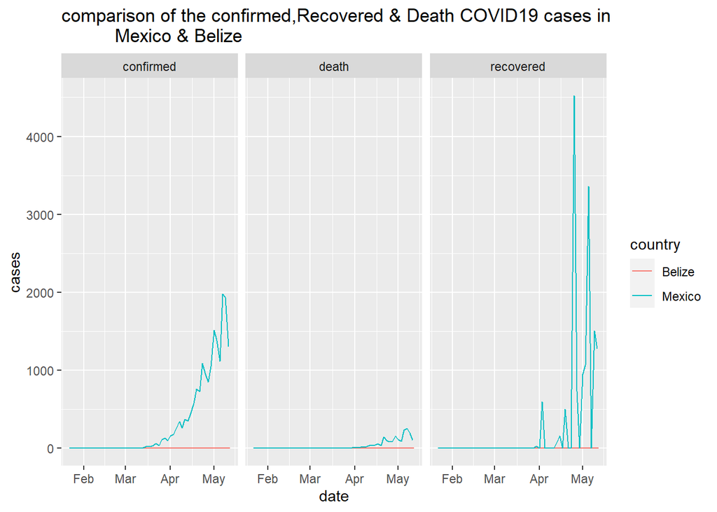

Belize has very few cases and deaths compared to Mexico, but Mexico reached a satisfactory recovered rate to Belize.

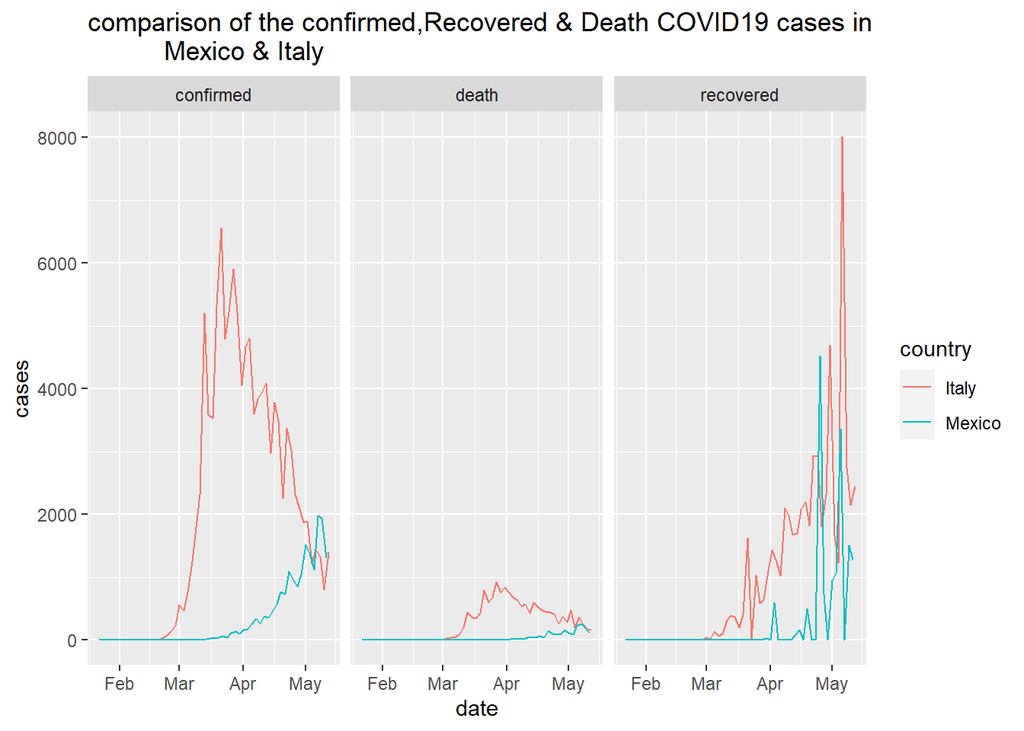

Italy has passed their peak season while Mexico is still increasing. However Italy has reached better recovery rate.

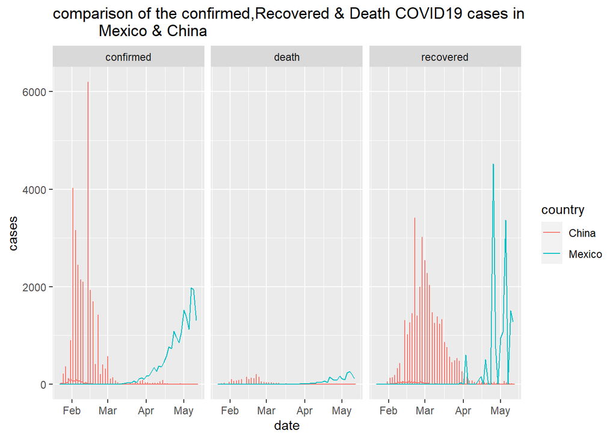

China has passed their peak season before Mexico reach to an endemic level. However Mexico has reported high death rate than China.

# $\underline{Conclusion\space and\space Discussion}$

The US-Mexico border has long been a region of contrasts.But people in both countries are puzzling over the latest one,The number of confirmed cases of the coronavirus on the Mexican side is just a small fraction of the US count.China has passed their peak season before Mexico reach to an endemic level. However Mexico has reported high death rate than China. Belize & Guatemala have very few cases and deaths compared to Mexico, but Mexico reached a satisfactory recovered rate to Belize & Guatemala.

There are also concerns that the actual COVID-19 death count is underreported in Mexico,as the reported deathcount only includes people who tested positive for COVID-19 and died in hospitals.The reported death figures on a given date does not necessarily show the number of new deaths on that day this is due to delays.

# $\underline{References}$

- www.bbc.com
- www.liveandinvestoverseas.com
- https://ourworldindata.org